# Plot Social Networks

Miriam Schwyck

2025-03-25

## Read in data

Here, we assume that the data is stored in the same directory as this script.

```r
# set your working directory - change this to wherever you saved this script and the data file(s)
wd <- "./"

# read in data in edge list form
edgelist_data <- read.csv(paste0(wd,"social_network_edgelist.csv"))

# look at data
edgelist_data
```

```
##      node1   node2    weight
## 1    Alice     Bob 0.5113719
## 2    Alice    Dave 0.5982411
## 3    Alice     Eve 1.7492505
## 4     Judy  Faythe 1.4347515
## 5    Alice   Grace 1.8638134
## 6    Alice   Heidi 1.7561457
## 7    Alice    Ivan 0.2625327
## 8      Bob Charlie 1.5316854
## 9      Bob     Eve 1.7550330
## 10 Charlie     Eve 1.3194334
## 11   Grace   Heidi 1.1921487
## 12   Grace    Ivan 1.1497345
## 13   Grace    Judy 0.6214490
## 14   Heidi    Ivan 1.2230480
## 15   Heidi    Judy 0.3665718
## 16    Ivan    Judy 0.1521669
```

```r
head(edgelist_data)
```

```
##   node1  node2    weight
## 1 Alice    Bob 0.5113719
## 2 Alice   Dave 0.5982411
## 3 Alice    Eve 1.7492505
## 4  Judy Faythe 1.4347515
## 5 Alice  Grace 1.8638134
## 6 Alice  Heidi 1.7561457
```

```r
View(edgelist_data)
```

## Make and view the network

```r
# make the graph object
g <- graph_from_data_frame(edgelist_data, directed=FALSE)
g
```

```
## IGRAPH cad4c7b UNW- 10 16 --
## + attr: name (v/c), weight (e/n)
## + edges from cad4c7b (vertex names):
##  [1] Alice  --Bob     Alice  --Dave    Alice  --Eve     Judy   --Faythe
##  [5] Alice  --Grace   Alice  --Heidi   Alice  --Ivan    Bob    --Charlie
##  [9] Bob    --Eve     Charlie--Eve     Grace  --Heidi   Grace  --Ivan
## [13] Judy   --Grace   Heidi  --Ivan    Judy   --Heidi   Judy   --Ivan
```

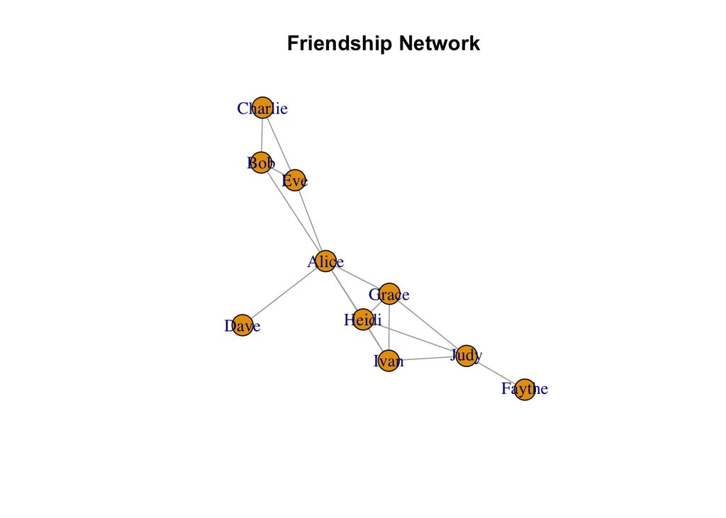

```r
# plot the graph
plot(g, main="Friendship Network")
```

```r
# Get the adjacency matrix
get.adjacency(g, sparse=FALSE)
```

```
##         Alice Judy Bob Charlie Grace Heidi Ivan Dave Eve Faythe
## Alice       0    0   1       0     1     1    1    1   1      0
## Judy        0    0   0       0     1     1    1    0   0      1
## Bob         1    0   0       1     0     0    0    0   1      0
## Charlie     0    0   1       0     0     0    0    0   1      0
## Grace       1    1   0       0     0     1    1    0   0      0
## Heidi       1    1   0       0     1     0    1    0   0      0
## Ivan        1    1   0       0     1     1    0    0   0      0
## Dave        1    0   0       0     0     0    0    0   0      0
## Eve         1    0   1       1     0     0    0    0   0      0
## Faythe      0    1   0       0     0     0    0    0   0      0
```

```r
# Get the weighted adjacency matrix
get.adjacency(g, attr="weight", sparse=FALSE)
```

```
##             Alice      Judy       Bob  Charlie    Grace     Heidi      Ivan
## Alice   0.0000000 0.0000000 0.5113719 0.000000 1.863813 1.7561457 0.2625327
## Judy    0.0000000 0.0000000 0.0000000 0.000000 0.621449 0.3665718 0.1521669
## Bob     0.5113719 0.0000000 0.0000000 1.531685 0.000000 0.0000000 0.0000000
## Charlie 0.0000000 0.0000000 1.5316854 0.000000 0.000000 0.0000000 0.0000000
## Grace   1.8638134 0.6214490 0.0000000 0.000000 0.000000 1.1921487 1.1497345
## Heidi   1.7561457 0.3665718 0.0000000 0.000000 1.192149 0.0000000 1.2230480
## Ivan    0.2625327 0.1521669 0.0000000 0.000000 1.149735 1.2230480 0.0000000
## Dave    0.5982411 0.0000000 0.0000000 0.000000 0.000000 0.0000000 0.0000000
## Eve     1.7492505 0.0000000 1.7550330 1.319433 0.000000 0.0000000 0.0000000
## Faythe  0.0000000 1.4347515 0.0000000 0.000000 0.000000 0.0000000 0.0000000
##              Dave      Eve   Faythe
## Alice   0.5982411 1.749251 0.000000
## Judy    0.0000000 0.000000 1.434751
## Bob     0.0000000 1.755033 0.000000
## Charlie 0.0000000 1.319433 0.000000
## Grace   0.0000000 0.000000 0.000000
## Heidi   0.0000000 0.000000 0.000000
## Ivan    0.0000000 0.000000 0.000000
## Dave    0.0000000 0.000000 0.000000
## Eve     0.0000000 0.000000 0.000000
## Faythe  0.0000000 0.000000 0.000000
```

### EXERCISE: Make a directed graph and plot it.

Notice that when we created the graph object, we set the “directed” argument to False. To create a directed graph (i.e., one where Alice might like Bob but Bob might not like Alice), change that argument to True.

```r
# make a directed graph object and plot it here
```

## Vertices/Nodes

```r
# get the vertices/nodes/people
V(g)
```

```
## + 10/10 vertices, named, from cad4c7b:
##  [1] Alice   Judy    Bob     Charlie Grace   Heidi   Ivan    Dave    Eve
## [10] Faythe
```

```r
# get number of vertices (i.e., number of people in the network)
n_vertices <- length(V(g))
n_vertices
```

```
## [1] 10
```

### Get/Set node attributes

Attributes that are stored in the graph object

```r
# get the names of the people/nodes/vertices
V(g)$name
```

```
##  [1] "Alice"   "Judy"    "Bob"     "Charlie" "Grace"   "Heidi"   "Ivan"
##  [8] "Dave"    "Eve"     "Faythe"
```

Add attributes

```r
# add age to the graph object
ages <- c(19, 20, 21, 22, 25, 30, 18, 19, 33, 28)
V(g)$age <- ages
print(V(g)$age)
```

```
##  [1] 19 20 21 22 25 30 18 19 33 28
```

Change plot to reflect age

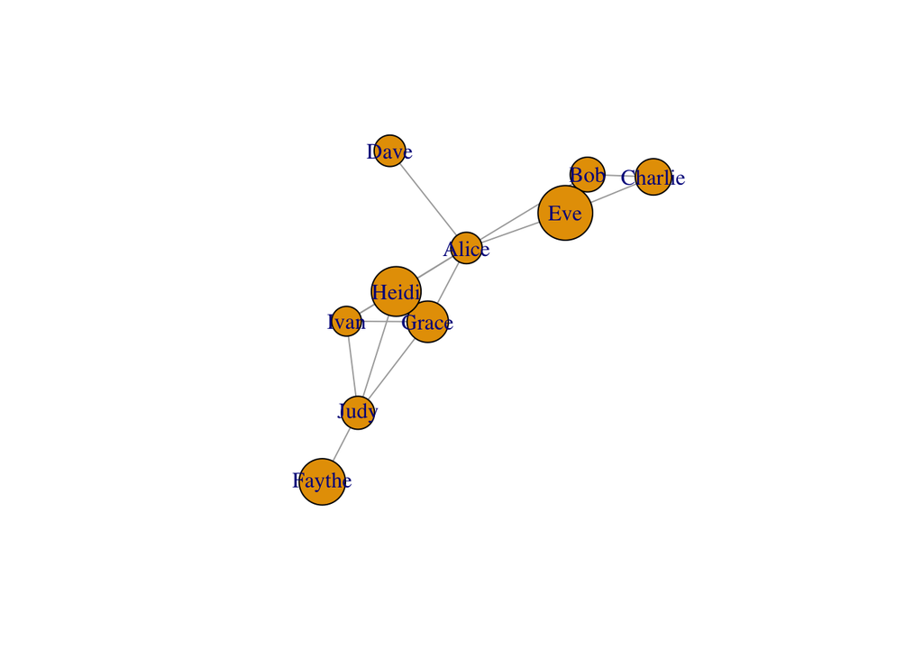

```r
# "size" is a special attribute that plot() knows, so you can set it equal to any
# attribute to visualize that attribute in the plot
V(g)$size <- V(g)$age
# plot again
plot(g)
```

#### EXERCISE: Add another node attribute (e.g., height) and plot the graph that reflects that attribute

### Calculate node-level social network measures

#### Degree

Degree is the number of edges a node has

```r
# get the number of friends each person has (i.e., degree)
degree(g)
```

```
##   Alice    Judy     Bob Charlie   Grace   Heidi    Ivan    Dave     Eve  Faythe
##       6       4       3       2       4       4       4       1       3       1
```

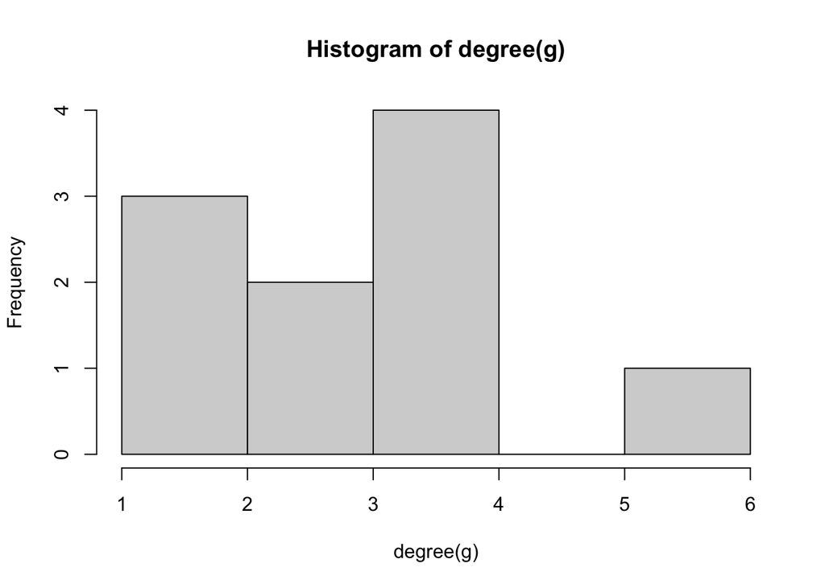

```r
hist(degree(g))
```

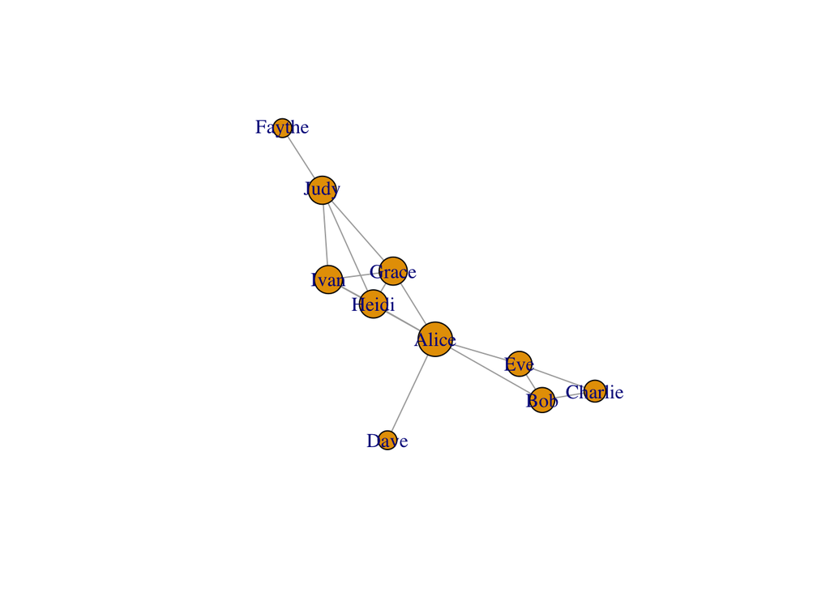

```r
# change the size of the vertex based on that vertex's degree
V(g)$size <- degree(g)*2 + 10
plot(g)
```

In a directed graph, there are two types of degree: in-degree (the number of ties pointing into a node)

```r
degree(g, mode="in")
```

```
##   Alice    Judy     Bob Charlie   Grace   Heidi    Ivan    Dave     Eve  Faythe
##       6       4       3       2       4       4       4       1       3       1
```

out-degree (the number of ties pointing out of a node)

```r
degree(g, mode="out")
```

```
##   Alice    Judy     Bob Charlie   Grace   Heidi    Ivan    Dave     Eve  Faythe
##       6       4       3       2       4       4       4       1       3       1
```

#### Strength

Strength is the sum of the weighted edges connected to a node

```r
strength(g)
```

```
##     Alice      Judy       Bob   Charlie     Grace     Heidi      Ivan      Dave
## 6.7413554 2.5749392 3.7980903 2.8511188 4.8271457 4.5379143 2.7874821 0.5982411
##       Eve    Faythe
## 4.8237170 1.4347515
```

#### Eigenvector Centrality

Eigenvector Centrality measures the extent to which a node is connected to other well-connected nodes.

```r
eigen_centrality(g)
```

```
## $vector
##      Alice       Judy        Bob    Charlie      Grace      Heidi       Ivan
## 1.00000000 0.20459036 0.53304847 0.39549873 0.76480809 0.74259104 0.46643896
##       Dave        Eve     Faythe
## 0.13407693 0.71865909 0.06578693
##
## $value
## [1] 4.461924
##
## $options
## $options$bmat
## [1] "I"
##
## $options$n
## [1] 10
##
## $options$which
## [1] "LA"
##
## $options$nev
## [1] 1
##
## $options$tol
## [1] 0
##
## $options$ncv
## [1] 0
##
## $options$ldv
## [1] 0
##
## $options$ishift
## [1] 1
##
## $options$maxiter
## [1] 1000
##
## $options$nb
## [1] 1
##
```

[output cut: 14 more lines]

```
##
## $options$iter
## [1] 8
##
## $options$nconv
## [1] 1
##
## $options$numop
## [1] 26
##
## $options$numopb
## [1] 0
##
## $options$numreo
## [1] 15
```

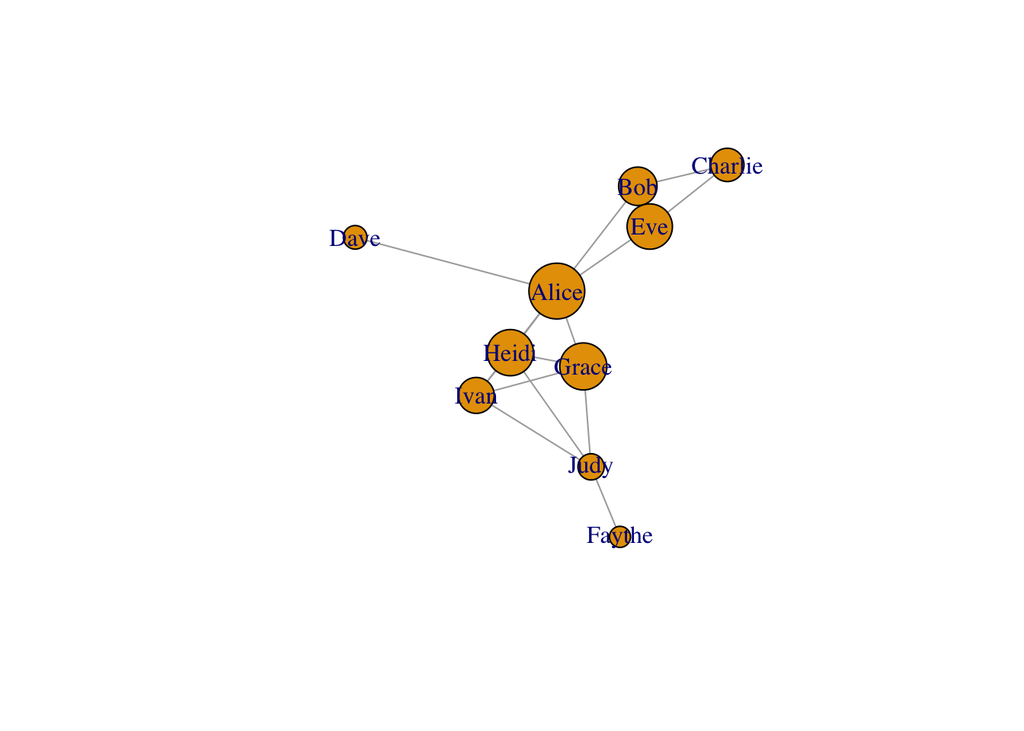

```r
# notice that it's not just a list of values, so for this one, we have to select the "vector" variable
evc <- eigen_centrality(g)$vector

V(g)$size <- evc*20+10
plot(g)
```

#### Brokerage

Betweenness is the extent to which a node sits on the shortest path between two other nodes. In other words, how often do you have to go through that node to reach other nodes?

```r
betweenness(g)
```

```
##   Alice    Judy     Bob Charlie   Grace   Heidi    Ivan    Dave     Eve  Faythe
##      23      21       7       0       0       0      20       0       0       0
```

Constraint is an inverse measure of brokerage. It reflects the extent to which a node is constrained to its local area.

```r
constraint(g)
```

```
##     Alice      Judy       Bob   Charlie     Grace     Heidi      Ivan      Dave
## 0.4041695 0.4782960 0.8392543 1.0034147 0.6087235 0.6549479 0.8492998 1.0000000
##       Eve    Faythe
## 0.6358031 1.0000000
```

##### EXERCISE: Change the node size of the plot to reflect betweenness?

##### EXERCISE: Change the node size of the plot to reflect constraint?

## Edges

```r
# get edges/ties/friendships
E(g)
```

```
## + 16/16 edges from cad4c7b (vertex names):
##  [1] Alice  --Bob     Alice  --Dave    Alice  --Eve     Judy   --Faythe
##  [5] Alice  --Grace   Alice  --Heidi   Alice  --Ivan    Bob    --Charlie
##  [9] Bob    --Eve     Charlie--Eve     Grace  --Heidi   Grace  --Ivan
## [13] Judy   --Grace   Heidi  --Ivan    Judy   --Heidi   Judy   --Ivan
```

```r
# print out each edge ID in a for-loop
for (edge in E(g)) {
  # get edge id
  print(edge)
  # get edge's vertices
  print(E(g)[edge])
}
```

```
## [1] 1
## + 1/16 edge from cad4c7b (vertex names):
## [1] Alice--Bob
## [1] 2
## + 1/16 edge from cad4c7b (vertex names):
## [1] Alice--Dave
## [1] 3
## + 1/16 edge from cad4c7b (vertex names):
## [1] Alice--Eve
## [1] 4
## + 1/16 edge from cad4c7b (vertex names):
## [1] Judy--Faythe
## [1] 5
## + 1/16 edge from cad4c7b (vertex names):
## [1] Alice--Grace
## [1] 6
## + 1/16 edge from cad4c7b (vertex names):
## [1] Alice--Heidi
## [1] 7
## + 1/16 edge from cad4c7b (vertex names):
## [1] Alice--Ivan
## [1] 8
## + 1/16 edge from cad4c7b (vertex names):
## [1] Bob--Charlie
## [1] 9
## + 1/16 edge from cad4c7b (vertex names):
## [1] Bob--Eve
## [1] 10
## + 1/16 edge from cad4c7b (vertex names):
## [1] Charlie--Eve
## [1] 11
## + 1/16 edge from cad4c7b (vertex names):
## [1] Grace--Heidi
## [1] 12
## + 1/16 edge from cad4c7b (vertex names):
## [1] Grace--Ivan
## [1] 13
## + 1/16 edge from cad4c7b (vertex names):
## [1] Judy--Grace
## [1] 14
## + 1/16 edge from cad4c7b (vertex names):
## [1] Heidi--Ivan
## [1] 15
## + 1/16 edge from cad4c7b (vertex names):
## [1] Judy--Heidi
## [1] 16
## + 1/16 edge from cad4c7b (vertex names):
## [1] Judy--Ivan
```

### Get edge attributes

```r
E(g)$weight
```

```
##  [1] 0.5113719 0.5982411 1.7492505 1.4347515 1.8638134 1.7561457 0.2625327
##  [8] 1.5316854 1.7550330 1.3194334 1.1921487 1.1497345 0.6214490 1.2230480
## [15] 0.3665718 0.1521669
```

Plot graph based on attributes

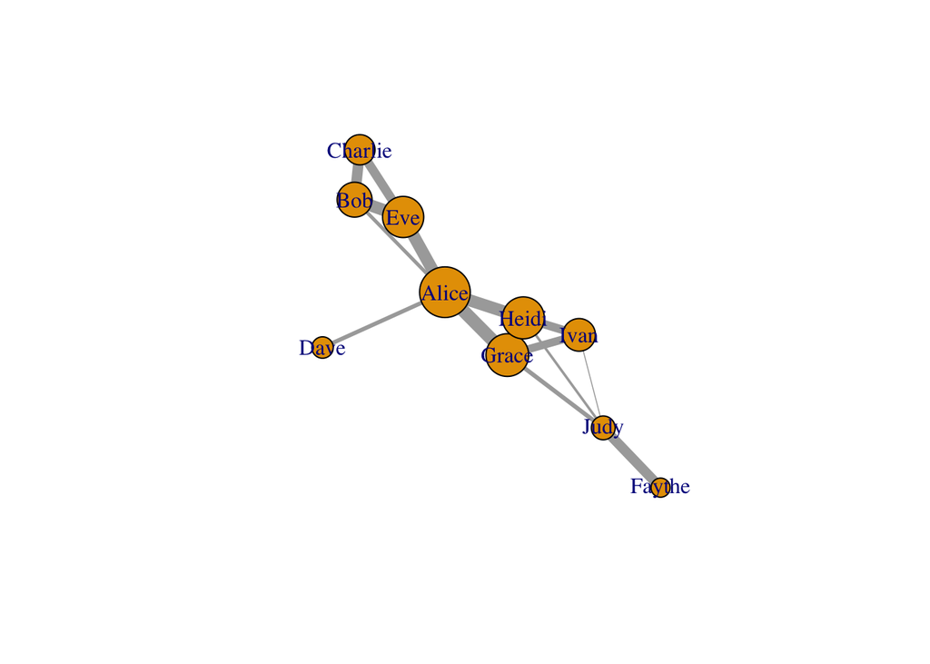

```r
# make ties in plot thicker based on how strong (either positive or negative) their relationship is
E(g)$width <- abs(E(g)$weight)*5
# plot with weight
plot(g)
```

```r
# add color attribute to each edge
for (edge in E(g)) {
  # get edge id
  print(edge)
  # get edge weight
  edge_weight <- E(g)[edge]$weight
  # determine if edge was positive or negative
  # if positive, make the edge green
  # if negative, make the edge red
  if (edge_weight >= 1) {
    edge_color <- "blue"
  } else {
    edge_color <- "darkred"
  }
  E(g)[edge]$color <- edge_color
}
```

```
## [1] 1
## [1] 2
## [1] 3
## [1] 4
## [1] 5
## [1] 6
## [1] 7
## [1] 8
## [1] 9
## [1] 10
## [1] 11
## [1] 12
## [1] 13
## [1] 14
## [1] 15
## [1] 16
```

```r
# look at edge attributes
E(g)$weight
```

```
##  [1] 0.5113719 0.5982411 1.7492505 1.4347515 1.8638134 1.7561457 0.2625327
##  [8] 1.5316854 1.7550330 1.3194334 1.1921487 1.1497345 0.6214490 1.2230480
## [15] 0.3665718 0.1521669
```

```r
E(g)$color
```

```
##  [1] "darkred" "darkred" "blue"    "blue"    "blue"    "blue"    "darkred"
##  [8] "blue"    "blue"    "blue"    "blue"    "blue"    "darkred" "blue"
## [15] "darkred" "darkred"
```

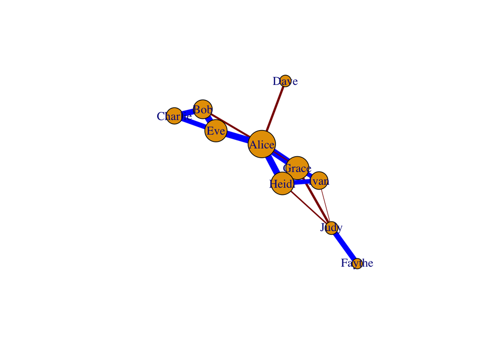

```r
# plot with edge weight and color
plot(g)
```

#### EXERCISE: Add another edge attribute and plot the graph that reflects that attribute

### Calculate other social network measures

#### Triads

```r
# https://r.igraph.org/reference/triad_census.html
triad_census(g)
```

```
##  [1] 29  0 63  0  0  0  0  0  0  0 19  0  0  0  0  9
```

```r
triad_count_0 <- triad_census(g)[1]
triad_count_1 <- triad_census(g)[3]
triad_count_2 <- triad_census(g)[11]
triad_count_3 <- triad_census(g)[16]
# get the probability that adjacent vertices of a vertex are connected (i.e., if two nodes share a friend, are they also friends)
transitivity(g)
```

```
## [1] 0.5869565
```

#### Clustering

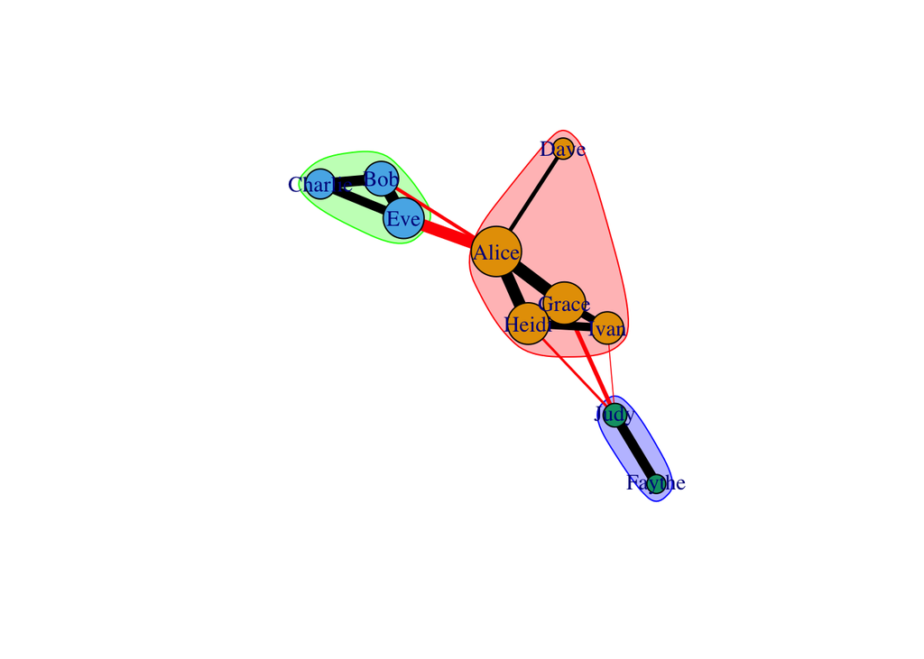

```r
com <- fastgreedy.community(g)
mem <- membership(com)
plot(com, g)
```